Nada Ardelia  
G1401231011

# Packages

```
##
##  C:\Users\ailed\AppData\Local\Temp\RtmpSWKydv\downloaded_packages
```

```r
library(forecast)
library(graphics)
library(TTR)
library(TSA)
library(rio)
```

```r
library(ggplot2)
library(tseries)
```

# Data

```r
data <- read.csv("C:\\Users\\ailed\\Downloads\\Telur Ayam Ras.csv")
head(data)
```

```
##         Date Jawa.Barat
## 1 2022-07-14      27680
## 2 2022-07-15      27920
## 3 2022-07-16      27960
## 4 2022-07-17      27890
## 5 2022-07-18      27950
## 6 2022-07-19      28260
```

```r
data_subset <- data[160:319, ]
head(data_subset)
```

```
##           Date Jawa.Barat
## 160 2022-12-20      30500
## 161 2022-12-21      30400
## 162 2022-12-22      30200
## 163 2022-12-23      29880
## 164 2022-12-24      29810
## 165 2022-12-25      30050
```

```r
data_subset$Date <- as.Date(data_subset$Date) # buat ubah format date
```

```r
str(data_subset)
```

```
## 'data.frame':    160 obs. of  2 variables:
##  $ Date      : Date, format: "2022-12-20" "2022-12-21" ...
##  $ Jawa.Barat: int  30500 30400 30200 29880 29810 30050 29680 29410 29230 29130 ...
```

```r
# jumlah baris data
n <- nrow(data_subset)

# hitung batas 80%
n_train <- floor(0.8 * n)

# bagi data
training <- data_subset[1:n_train, ]
testing  <- data_subset[(n_train+1):n, ]

# ubah ke time series
train.ts <- ts(training$Jawa.Barat)
test.ts  <- ts(testing$Jawa.Barat)
```

```r
ts_data <- ts(data_subset$Jawa.Barat, freq=1) # kalo freq 1 dianggep pure daily ga ada seasonality
```

# Eksplorasi Data

```r
summary(ts_data)
```

```
##    Min. 1st Qu.  Median    Mean 3rd Qu.    Max.
##   26910   27845   28335   28737   29463   32070
```

## Plot Data

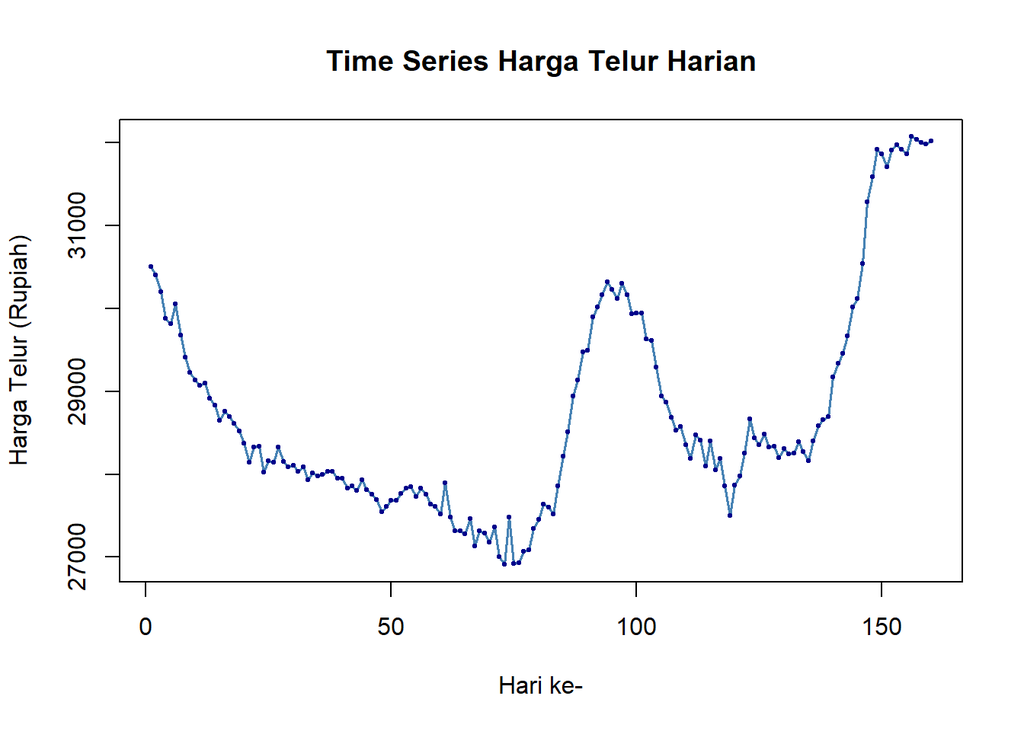

```r
plot(ts_data,
     main = "Time Series Harga Telur Harian",
     xlab = "Hari ke-",
     ylab = "Harga Telur (Rupiah)",
     type = "l",
     col = "steelblue",
     lwd = 1.5)
points(ts_data, pch = 19, cex = 0.4, col = "darkblue")
```

## Plot Data Train

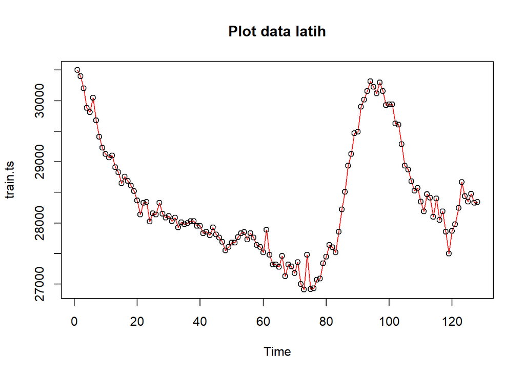

```r
plot(train.ts, col="red",main="Plot data latih")
points(train.ts)
```

## Plot Data Test

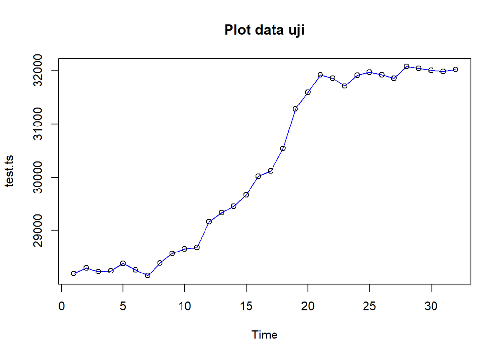

```r
plot(test.ts, col="blue",main="Plot data uji")
points(test.ts)
```

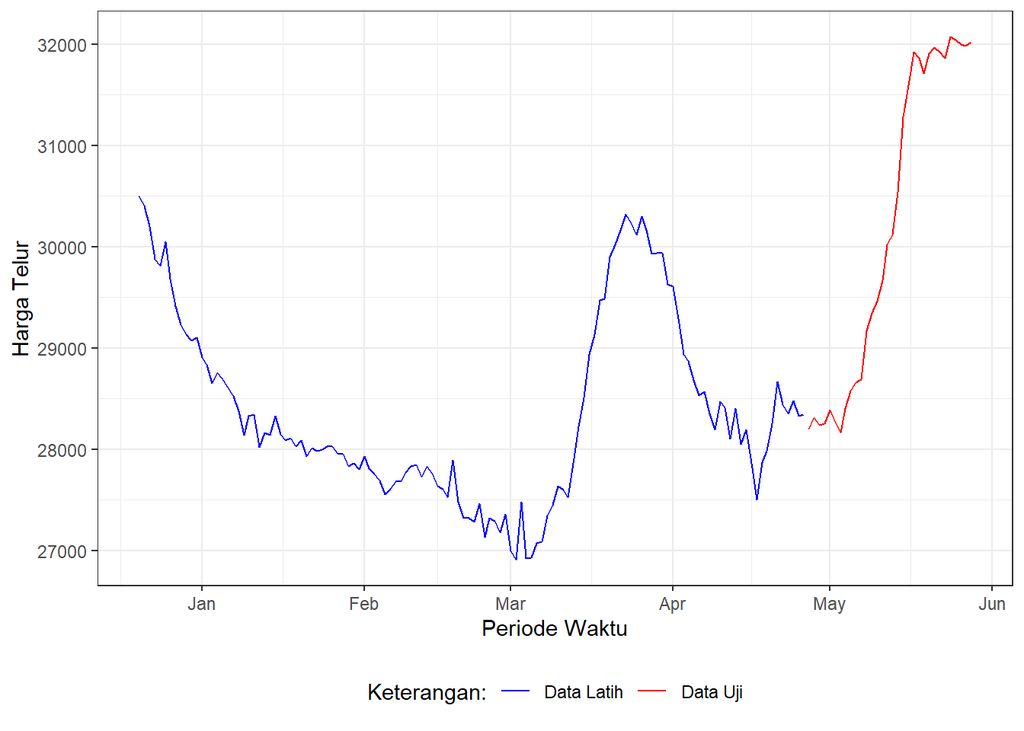

```r
ggplot() +
  geom_line(data = training, aes(x = Date, y = Jawa.Barat, col = "Data Latih")) +
  geom_line(data = testing, aes(x = Date, y = Jawa.Barat, col = "Data Uji")) +
  labs(x = "Periode Waktu", y = "Harga Telur", color = "Legend") +
  scale_colour_manual(name="Keterangan:", breaks = c("Data Latih", "Data Uji"),
                      values = c("blue", "red")) +
  theme_bw() + theme(legend.position = "bottom",
                     plot.caption = element_text(hjust=0.5, size=12))
```

## Cek Seasonal

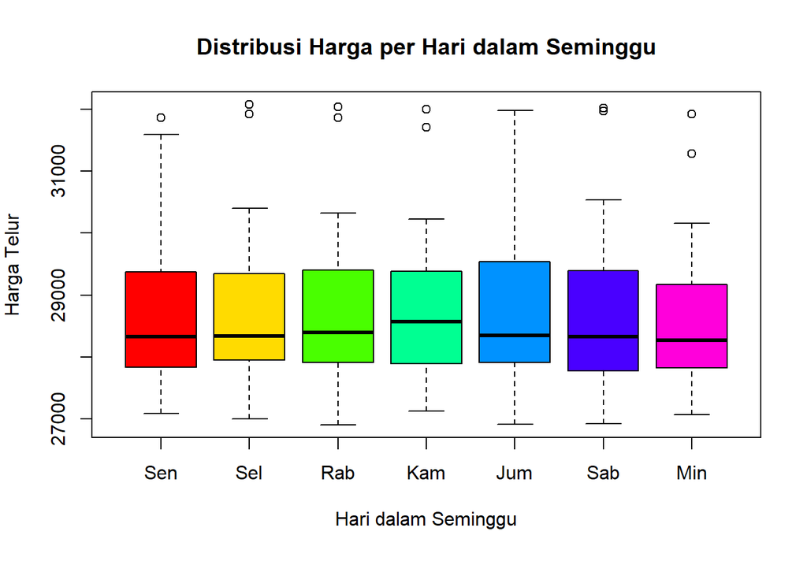

```
##
## === SEASONAL ANALYSIS ===
## ANOVA p-value untuk efek hari: 0.9998
## Tidak ada pola seasonal yang signifikan
```

```r
if(length(ts_data) >= 14) {
  # Create day of week indicator
  days_of_week <- rep(1:7, length.out = length(ts_data))
  day_names <- c("Sen", "Sel", "Rab", "Kam", "Jum", "Sab", "Min")

  # Boxplot per hari dalam seminggu
  par(mar = c(6, 4, 4, 2))
  boxplot(as.numeric(ts_data) ~ days_of_week,
          main = "Distribusi Harga per Hari dalam Seminggu",
          xlab = "Hari dalam Seminggu",
          ylab = "Harga Telur",
          names = day_names,
          col = rainbow(7))

  # ANOVA test untuk seasonality
  seasonal_test <- aov(as.numeric(ts_data) ~ as.factor(days_of_week))
  seasonal_pvalue <- summary(seasonal_test)[[1]][1, "Pr(>F)"]

  cat("\n=== SEASONAL ANALYSIS ===\n")
  cat("ANOVA p-value untuk efek hari:", round(seasonal_pvalue, 4), "\n")
  if(seasonal_pvalue < 0.05) {
    cat("Ada pola seasonal mingguan yang signifikan!\n")
    use_seasonal <- TRUE
  } else {
    cat("Tidak ada pola seasonal yang signifikan\n")
    use_seasonal <- FALSE
  }
} else {
  cat("Data terlalu pendek untuk analisis seasonal\n")
  use_seasonal <- FALSE
}
```

Pada grafik terlihat ada tren naik dan turun yang jelas dan berdasarkan hasil ANOVA tidak ada pola seasonal mingguan yang signifikan sehingga harga telur tidak berbeda signifikan antara Senin-Minggu. Dari boxplot juga terlihat distribusinya relatif sama di semua hari. Hal ini menunjukkan bahwa metode *Holt-Winter’s tidak diperlukan karena tidak ada seasonality sehingga cukup menggunaka Double Exponential Smoothing (DES).*

# Double Exponential Smoothing (DES)

## Lambda dan beta optimum

```r
des.opt<- HoltWinters(train.ts, gamma = FALSE)
des.opt
```

```
## Holt-Winters exponential smoothing with trend and without seasonal component.
##
## Call:
## HoltWinters(x = train.ts, gamma = FALSE)
##
## Smoothing parameters:
##  alpha: 0.7093164
##  beta : 0.2826432
##  gamma: FALSE
##
## Coefficients:
##            [,1]
## a 28357.4943218
## b    -0.6042308
```

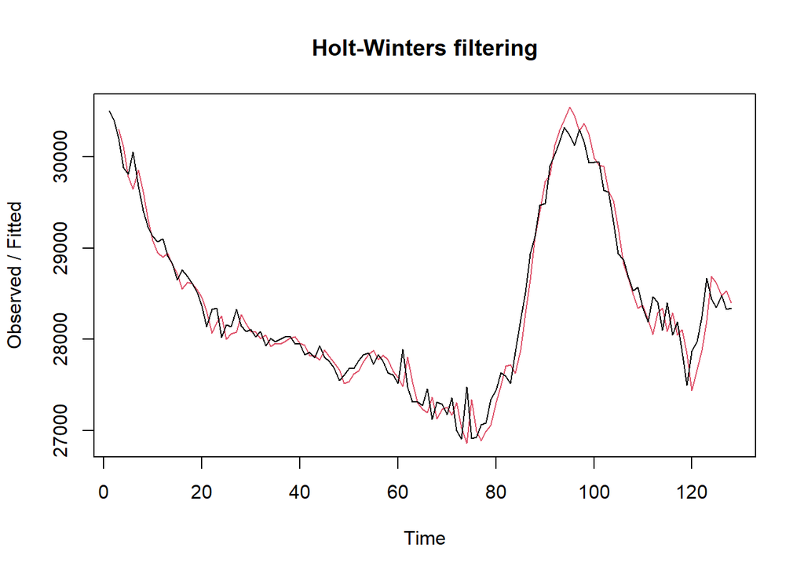

```r
plot(des.opt)
```

```r
#ramalan
ramalandesopt<- forecast(des.opt, h=32)
ramalandesopt
```

```
##     Point Forecast    Lo 80    Hi 80    Lo 95    Hi 95
## 129       28356.89 28107.00 28606.78 27974.72 28739.06
## 130       28356.29 28018.45 28694.12 27839.61 28872.96
## 131       28355.68 27918.52 28792.84 27687.10 29024.26
## 132       28355.08 27808.82 28901.33 27519.65 29190.50
## 133       28354.47 27690.39 29018.56 27338.84 29370.10
## 134       28353.87 27563.95 29143.79 27145.79 29561.95
## 135       28353.26 27430.06 29276.47 26941.35 29765.18
## 136       28352.66 27289.17 29416.16 26726.18 29979.14
## 137       28352.06 27141.62 29562.49 26500.86 30203.25
## 138       28351.45 26987.74 29715.16 26265.84 30437.07
## 139       28350.85 26827.79 29873.91 26021.53 30680.16
## 140       28350.24 26662.00 30038.49 25768.29 30932.19
## 141       28349.64 26490.57 30208.71 25506.44 31192.84
## 142       28349.04 26313.70 30384.37 25236.26 31461.81
```

[output cut: 18 more lines]

```r
cat("Panjang forecast:", length(ramalandesopt$mean), "\n")
```

```
## Panjang forecast: 32
```

```r
cat("Panjang testing:", length(test.ts), "\n")
```

```
## Panjang testing: 32
```

Panjang atau h nya harus sama

### Akurasi Data Latih

```r
#Akurasi Data Training
ssedes.train<-des.opt$SSE
msedes.train<-ssedes.train/length(train.ts)
sisaandes<-ramalandesopt$residuals
head(sisaandes)
```

```
## Time Series:
## Start = 1
## End = 6
## Frequency = 1
## [1]         NA         NA -100.00000 -229.02001   29.39073  408.61413
```

```r
mapedes.train <- sum(abs(sisaandes[3:length(train.ts)]/train.ts[3:length(train.ts)])
                      *100)/length(train.ts)

akurasides.opt <- matrix(c(ssedes.train,msedes.train,mapedes.train))
row.names(akurasides.opt)<- c("SSE", "MSE", "MAPE")
colnames(akurasides.opt) <- c("Akurasi Optimum")

akurasides.opt
```

```
##      Akurasi Optimum
## SSE     4.754527e+06
## MSE     3.714474e+04
## MAPE    5.287005e-01
```

### Akurasi Data Uji

```r
#Akurasi Data Testing

selisihdes <- ramalandesopt$mean - testing$Jawa.Barat
selisihdes
```

```
## Time Series:
## Start = 129
## End = 160
## Frequency = 1
##  [1]   156.89009    46.28586   115.68163   105.07740   -35.52683    83.86894
##  [7]   193.26471   -47.33952  -227.94376  -308.54799  -339.15222  -819.75645
## [13]  -990.36068 -1110.96491 -1321.56914 -1672.17337 -1772.77760 -2193.38183
## [19] -2933.98606 -3244.59029 -3575.19452 -3515.79876 -3366.40299 -3567.00722
## [25] -3627.61145 -3578.21568 -3518.81991 -3729.42414 -3700.02837 -3660.63260
## [31] -3641.23683 -3681.84106
```

```r
SSEtestingdes<-sum(selisihdes^2)
MSEtestingdes<-SSEtestingdes/length(testing$Jawa.Barat)
MAPEtestingdes<-sum(abs(selisihdes/testing$Jawa.Barat)*100)/length(testing$Jawa.Barat)
```

```r
akurasitestingdes <-
  matrix(c(SSEtestingdes,MSEtestingdes,MAPEtestingdes),
         nrow=3,ncol=1)
row.names(akurasitestingdes)<- c("SSE", "MSE", "MAPE")
colnames(akurasitestingdes) <- c("des")
akurasitestingdes
```

```
##               des
## SSE  1.902383e+08
## MSE  5.944946e+06
## MAPE 6.052033e+00
```

## Lambda 0,6 dan beta 0,3

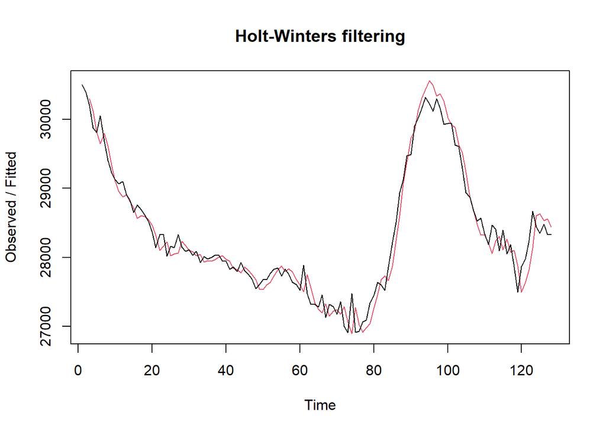

```r
des.2<- HoltWinters(train.ts, gamma = FALSE, beta = 0.3, alpha = 0.6)
plot(des.2)
```

```r
ramalandes2<- forecast(des.2, h=32)
ramalandes2
```

```
##     Point Forecast    Lo 80    Hi 80    Lo 95    Hi 95
## 129       28382.69 28130.50 28634.88 27997.00 28768.38
## 130       28384.10 28064.27 28703.93 27894.96 28873.24
## 131       28385.51 27984.38 28786.64 27772.03 28998.99
## 132       28386.92 27893.40 28880.44 27632.15 29141.69
## 133       28388.33 27793.04 28983.63 27477.91 29298.76
## 134       28389.74 27684.42 29095.06 27311.05 29468.43
## 135       28391.15 27568.37 29213.94 27132.81 29649.49
## 136       28392.56 27445.46 29339.67 26944.09 29841.03
## 137       28393.97 27316.16 29471.79 26745.60 30042.34
## 138       28395.38 27180.84 29609.93 26537.90 30252.87
## 139       28396.79 27039.79 29753.80 26321.44 30472.15
## 140       28398.21 26893.28 29903.13 26096.62 30699.79
## 141       28399.62 26741.52 30057.71 25863.78 30935.45
## 142       28401.03 26584.71 30217.34 25623.21 31178.84
```

[output cut: 18 more lines]

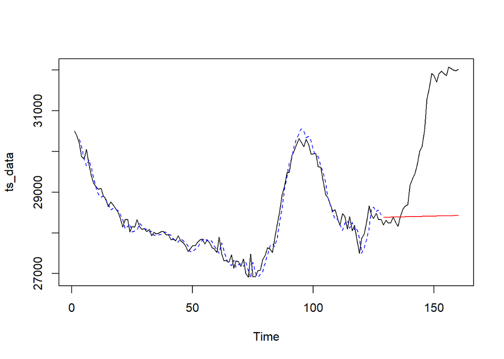

```r
plot(ts_data)
lines(des.2$fitted[,1], lty=2, col="blue")
lines(ramalandes2$mean, col="red")
```

### Akurasi Data Latih

```r
ssedes.train2<-des.2$SSE
msedes.train2<-ssedes.train2/length(train.ts)
sisaandes2<-ramalandes2$residuals
head(sisaandes2)
```

```
## Time Series:
## Start = 1
## End = 6
## Frequency = 1
## [1]        NA        NA -100.0000 -242.0000   -5.2400  400.4072
```

```r
mapedes.train2 <- sum(abs(sisaandes2[3:length(train.ts)]/train.ts[3:length(train.ts)])
                      *100)/length(train.ts)

akurasides.2 <- matrix(c(ssedes.train2,msedes.train2,mapedes.train2))
row.names(akurasides.2)<- c("SSE", "MSE", "MAPE")
colnames(akurasides.2) <- c("Akurasi lamda=0.6 dan gamma=0.3")
akurasides.2
```

```
##      Akurasi lamda=0.6 dan gamma=0.3
## SSE                     4.843014e+06
## MSE                     3.783605e+04
## MAPE                    5.366561e-01
```

### Akurasi Data Uji

```r
selisihdes2<-ramalandes2$mean-testing$Jawa.Barat
selisihdes2
```

```
## Time Series:
## Start = 129
## End = 160
## Frequency = 1
##  [1]   182.689136    74.099687   145.510238   136.920789    -1.668659
##  [6]   119.741892   231.152443    -7.437006  -186.026455  -264.615904
## [11]  -293.205353  -771.794801  -940.384250 -1058.973699 -1267.563148
## [16] -1616.152597 -1714.742046 -2133.331494 -2871.920943 -3180.510392
## [21] -3509.099841 -3447.689290 -3296.278739 -3494.868188 -3553.457636
## [26] -3502.047085 -3440.636534 -3649.225983 -3617.815432 -3576.404881
## [31] -3554.994329 -3593.583778
```

```r
SSEtestingdes2<-sum(selisihdes2^2)
MSEtestingdes2<-SSEtestingdes2/length(testing$Jawa.Barat)
MAPEtestingdes2<-sum(abs(selisihdes2/testing$Jawa.Barat)*100)/length(testing$Jawa.Barat)
```

```r
akurasitestingdes <-
  matrix(c(SSEtestingdes2,MSEtestingdes2,
           MAPEtestingdes2,SSEtestingdes,MSEtestingdes,MAPEtestingdes),
         nrow=3,ncol=2)
row.names(akurasitestingdes)<- c("SSE", "MSE", "MAPE")
colnames(akurasitestingdes) <- c("des ske2","des opt")
akurasitestingdes
```

```
##          des ske2      des opt
## SSE  1.817695e+08 1.902383e+08
## MSE  5.680298e+06 5.944946e+06
## MAPE 5.907658e+00 6.052033e+00
```

# Kesimpulan

Pada alpha dan beta optimum, *Training MAPE = 0,53%* dan *Testing MAPE 6,05%* ada gap sedikit yang menunjukkan model agak overfitting, tetapi skor MAPE < 10% sehingga model sudah cukup bagus.

Metode yang paling cocok untuk data_subset (160-319) harga telur ras di Jawa Barat adalah $Double Exponential Smooting (DES)$ dengan *alpha = 0,6 dan beta = 0,3.*